# Check this!

- 에러가 없을 때도 에러를 찾고 싶다.
- 오차가 작은 케이스도 있지만, 오차가 큰 케이스도 있다.
- 오차가 있을 때는, 특정 구간에서 오차가 크게 나는 것 같다.
- 분산은 오히려 오차가 크게 눈으로 보이는 곳 보다는, 기울기가 큰 곳이 분산이 더 큰 것 같다.
- 기존에 들어오는 데이터 셋과 차이가 있을 때 얘를 anomaly로 인식한다.

# How to measure?

## 고려해야 할 것

- 실시간 측정이 가능한가?
- 기존 데이터의 특성을 반영 할 수 있는가? *제일 걱정*
- 불량률이 아주 작아도 측정할 수 있는가?
- time cor.가 존재 하는가? (존재한다면, 최근 dx개만의 데이터셋과 비교?)

## 우리의 모델

- 에러를 두 단계로 측정한다. Warning, Danger
- 실시간으로 측정 가능한 cost가 작은 feature ex) dot product, diff sum

```python
import pandas as pd
import numpy as np
import matplotlib.pyplot as plt
%matplotlib inline
```

```python
data_1 = pd.read_csv('data_1.csv', header=None, index_col=None)
data_2 = pd.read_csv('data_2.csv', header=None, index_col=None)
data_3 = pd.read_csv('data_3.csv', header=None, index_col=None)
data_4 = pd.read_csv('data_4.csv', header=None, index_col=None)
data_5 = pd.read_csv('data_5.csv', header=None, index_col=None)

data_frame = np.array(data_1[list(range(2,np.shape(data_1)[1]))])
data_frame2 = np.array(data_2[list(range(2,np.shape(data_2)[1]))])
data_frame3 = np.array(data_3[list(range(2,np.shape(data_3)[1]))])
data_frame4 = np.array(data_4[list(range(2,np.shape(data_4)[1]))])
data_frame5 = np.array(data_5[list(range(2,np.shape(data_5)[1]))])

error_list1 = list(data_1[0])
error_list2 = list(data_2[0])
error_list3 = list(data_3[0])
error_list4 = list(data_4[0])
error_list5 = list(data_5[0])
```

```python
data_5
```

|  | 0 | 1 | 2 | 3 | 4 | 5 | 6 | 7 | 8 | 9 | ... | 148 | 149 | 150 | 151 | 152 | 153 | 154 | 155 | 156 | 157 |
| --- | --- | --- | --- | --- | --- | --- | --- | --- | --- | --- | --- | --- | --- | --- | --- | --- | --- | --- | --- | --- | --- |
| 0 | 0 | 2017.12.16 0:53 | 565 | 592 | 608 | 605 | 637 | 626 | 646 | 631 | ... | 0 | 0 | 0 | 0 | 0 | 0 | 0 | 0 | 0 | 0 |
| 1 | 0 | 2017.12.16 0:54 | 597 | 593 | 611 | 623 | 648 | 647 | 650 | 673 | ... | 0 | 0 | 0 | 0 | 0 | 0 | 0 | 0 | 0 | 0 |
| 2 | 0 | 2017.12.16 0:55 | 531 | 565 | 600 | 645 | 635 | 616 | 605 | 607 | ... | 0 | 0 | 0 | 0 | 0 | 0 | 0 | 0 | 0 | 0 |
| 3 | 0 | 2017.12.16 0:55 | 571 | 533 | 520 | 549 | 560 | 606 | 639 | 636 | ... | 0 | 0 | 0 | 0 | 0 | 0 | 0 | 0 | 0 | 0 |
| 4 | 0 | 2017.12.16 0:56 | 546 | 544 | 579 | 581 | 626 | 646 | 652 | 631 | ... | 0 | 0 | 0 | 0 | 0 | 0 | 0 | 0 | 0 | 0 |
| 5 | 0 | 2017.12.16 0:56 | 548 | 603 | 628 | 627 | 590 | 581 | 589 | 611 | ... | 0 | 0 | 0 | 0 | 0 | 0 | 0 | 0 | 0 | 0 |
| 6 | 0 | 2017.12.16 0:57 | 566 | 559 | 556 | 594 | 623 | 656 | 650 | 645 | ... | 0 | 0 | 0 | 0 | 0 | 0 | 0 | 0 | 0 | 0 |
| 7 | 0 | 2017.12.16 0:57 | 524 | 577 | 558 | 578 | 572 | 580 | 584 | 590 | ... | 0 | 0 | 0 | 0 | 0 | 0 | 0 | 0 | 0 | 0 |
| 8 | 0 | 2017.12.16 0:58 | 545 | 555 | 546 | 563 | 553 | 584 | 623 | 619 | ... | 0 | 0 | 0 | 0 | 0 | 0 | 0 | 0 | 0 | 0 |
| 9 | 0 | 2017.12.16 0:59 | 521 | 545 | 578 | 610 | 626 | 601 | 588 | 592 | ... | 0 | 0 | 0 | 0 | 0 | 0 | 0 | 0 | 0 | 0 |
| 10 | 0 | 2017.12.16 0:59 | 576 | 580 | 567 | 583 | 596 | 627 | 631 | 642 | ... | 0 | 0 | 0 | 0 | 0 | 0 | 0 | 0 | 0 | 0 |
| 11 | 0 | 2017.12.16 1:00 | 530 | 527 | 566 | 557 | 589 | 563 | 580 | 605 | ... | 0 | 0 | 0 | 0 | 0 | 0 | 0 | 0 | 0 | 0 |
| 12 | 0 | 2017.12.16 1:00 | 550 | 573 | 594 | 588 | 592 | 606 | 605 | 623 | ... | 0 | 0 | 0 | 0 | 0 | 0 | 0 | 0 | 0 | 0 |
| 13 | 0 | 2017.12.16 1:01 | 551 | 517 | 504 | 517 | 534 | 574 | 617 | 627 | ... | 0 | 0 | 0 | 0 | 0 | 0 | 0 | 0 | 0 | 0 |
| 14 | 0 | 2017.12.16 1:02 | 509 | 546 | 561 | 614 | 632 | 626 | 597 | 569 | ... | 0 | 0 | 0 | 0 | 0 | 0 | 0 | 0 | 0 | 0 |
| 15 | 0 | 2017.12.16 1:02 | 504 | 550 | 570 | 572 | 559 | 547 | 570 | 573 | ... | 0 | 0 | 0 | 0 | 0 | 0 | 0 | 0 | 0 | 0 |
| 16 | 0 | 2017.12.16 1:03 | 554 | 556 | 527 | 522 | 528 | 561 | 595 | 618 | ... | 0 | 0 | 0 | 0 | 0 | 0 | 0 | 0 | 0 | 0 |
| 17 | 0 | 2017.12.16 1:03 | 503 | 494 | 531 | 571 | 586 | 586 | 575 | 565 | ... | 0 | 0 | 0 | 0 | 0 | 0 | 0 | 0 | 0 | 0 |
| 18 | 0 | 2017.12.16 1:04 | 508 | 562 | 545 | 554 | 560 | 558 | 582 | 579 | ... | 0 | 0 | 0 | 0 | 0 | 0 | 0 | 0 | 0 | 0 |
| 19 | 0 | 2017.12.16 1:04 | 570 | 562 | 573 | 569 | 580 | 595 | 631 | 639 | ... | 0 | 0 | 0 | 0 | 0 | 0 | 0 | 0 | 0 | 0 |
| 20 | 0 | 2017.12.16 1:05 | 496 | 500 | 532 | 557 | 585 | 581 | 569 | 557 | ... | 0 | 0 | 0 | 0 | 0 | 0 | 0 | 0 | 0 | 0 |
| 21 | 0 | 2017.12.16 1:06 | 539 | 529 | 551 | 523 | 551 | 568 | 579 | 609 | ... | 0 | 0 | 0 | 0 | 0 | 0 | 0 | 0 | 0 | 0 |
| 22 | 0 | 2017.12.16 1:06 | 511 | 524 | 558 | 557 | 576 | 552 | 565 | 583 | ... | 0 | 0 | 0 | 0 | 0 | 0 | 0 | 0 | 0 | 0 |
| 23 | 0 | 2017.12.16 1:07 | 535 | 555 | 549 | 541 | 546 | 553 | 566 | 595 | ... | 0 | 0 | 0 | 0 | 0 | 0 | 0 | 0 | 0 | 0 |
| 24 | 0 | 2017.12.16 1:07 | 544 | 522 | 529 | 544 | 594 | 640 | 644 | 626 | ... | 0 | 0 | 0 | 0 | 0 | 0 | 0 | 0 | 0 | 0 |
| 25 | 0 | 2017.12.16 1:08 | 497 | 517 | 566 | 576 | 562 | 540 | 524 | 563 | ... | 0 | 0 | 0 | 0 | 0 | 0 | 0 | 0 | 0 | 0 |
| 26 | 0 | 2017.12.16 1:09 | 529 | 551 | 570 | 556 | 547 | 547 | 573 | 587 | ... | 0 | 0 | 0 | 0 | 0 | 0 | 0 | 0 | 0 | 0 |
| 27 | 0 | 2017.12.16 1:09 | 546 | 534 | 526 | 517 | 542 | 578 | 603 | 610 | ... | 0 | 0 | 0 | 0 | 0 | 0 | 0 | 0 | 0 | 0 |
| 28 | 0 | 2017.12.16 1:10 | 534 | 534 | 598 | 601 | 614 | 594 | 580 | 597 | ... | 0 | 0 | 0 | 0 | 0 | 0 | 0 | 0 | 0 | 0 |
| 29 | 0 | 2017.12.16 1:10 | 543 | 524 | 529 | 535 | 544 | 565 | 577 | 602 | ... | 0 | 0 | 0 | 0 | 0 | 0 | 0 | 0 | 0 | 0 |
| ... | ... | ... | ... | ... | ... | ... | ... | ... | ... | ... | ... | ... | ... | ... | ... | ... | ... | ... | ... | ... | ... |
| 1163 | 0 | 2017.12.19 7:41 | 488 | 479 | 444 | 475 | 503 | 549 | 567 | 551 | ... | 0 | 0 | 0 | 0 | 0 | 0 | 0 | 0 | 0 | 0 |
| 1164 | 0 | 2017.12.19 7:41 | 493 | 487 | 518 | 530 | 553 | 575 | 559 | 552 | ... | 0 | 0 | 0 | 0 | 0 | 0 | 0 | 0 | 0 | 0 |
| 1165 | 0 | 2017.12.19 7:42 | 484 | 497 | 516 | 509 | 503 | 488 | 502 | 540 | ... | 0 | 0 | 0 | 0 | 0 | 0 | 0 | 0 | 0 | 0 |
| 1166 | 0 | 2017.12.19 7:44 | 461 | 456 | 475 | 488 | 548 | 538 | 552 | 526 | ... | 0 | 0 | 0 | 0 | 0 | 0 | 0 | 0 | 0 | 0 |
| 1167 | 0 | 2017.12.19 7:44 | 501 | 524 | 507 | 506 | 513 | 513 | 542 | 554 | ... | 0 | 0 | 0 | 0 | 0 | 0 | 0 | 0 | 0 | 0 |
| 1168 | 0 | 2017.12.19 7:45 | 471 | 488 | 492 | 502 | 518 | 551 | 548 | 533 | ... | 0 | 0 | 0 | 0 | 0 | 0 | 0 | 0 | 0 | 0 |
| 1169 | 0 | 2017.12.19 7:46 | 490 | 524 | 509 | 504 | 503 | 499 | 539 | 540 | ... | 0 | 0 | 0 | 0 | 0 | 0 | 0 | 0 | 0 | 0 |
| 1170 | 0 | 2017.12.19 7:46 | 499 | 480 | 515 | 536 | 558 | 557 | 544 | 566 | ... | 0 | 0 | 0 | 0 | 0 | 0 | 0 | 0 | 0 | 0 |
| 1171 | 0 | 2017.12.19 7:47 | 522 | 501 | 499 | 515 | 517 | 545 | 570 | 578 | ... | 0 | 0 | 0 | 0 | 0 | 0 | 0 | 0 | 0 | 0 |
| 1172 | 0 | 2017.12.19 7:47 | 472 | 470 | 486 | 509 | 533 | 557 | 530 | 524 | ... | 0 | 0 | 0 | 0 | 0 | 0 | 0 | 0 | 0 | 0 |
| 1173 | 0 | 2017.12.19 7:48 | 488 | 522 | 529 | 512 | 475 | 478 | 487 | 532 | ... | 0 | 0 | 0 | 0 | 0 | 0 | 0 | 0 | 0 | 0 |
| 1174 | 0 | 2017.12.19 7:49 | 519 | 491 | 484 | 507 | 520 | 566 | 588 | 583 | ... | 0 | 0 | 0 | 0 | 0 | 0 | 0 | 0 | 0 | 0 |
| 1175 | 0 | 2017.12.19 7:49 | 461 | 475 | 486 | 507 | 524 | 542 | 496 | 518 | ... | 0 | 0 | 0 | 0 | 0 | 0 | 0 | 0 | 0 | 0 |
| 1176 | 0 | 2017.12.19 7:50 | 508 | 493 | 483 | 467 | 501 | 520 | 557 | 564 | ... | 0 | 0 | 0 | 0 | 0 | 0 | 0 | 0 | 0 | 0 |
| 1177 | 0 | 2017.12.19 7:50 | 431 | 455 | 482 | 527 | 533 | 529 | 500 | 487 | ... | 0 | 0 | 0 | 0 | 0 | 0 | 0 | 0 | 0 | 0 |
| 1178 | 0 | 2017.12.19 7:51 | 487 | 509 | 508 | 511 | 499 | 508 | 502 | 539 | ... | 0 | 0 | 0 | 0 | 0 | 0 | 0 | 0 | 0 | 0 |
| 1179 | 0 | 2017.12.19 7:51 | 505 | 509 | 491 | 495 | 485 | 513 | 559 | 553 | ... | 0 | 0 | 0 | 0 | 0 | 0 | 0 | 0 | 0 | 0 |
| 1180 | 0 | 2017.12.19 7:52 | 450 | 460 | 477 | 501 | 539 | 534 | 509 | 510 | ... | 0 | 0 | 0 | 0 | 0 | 0 | 0 | 0 | 0 | 0 |
| 1181 | 0 | 2017.12.19 7:53 | 478 | 487 | 474 | 487 | 505 | 526 | 533 | 531 | ... | 0 | 0 | 0 | 0 | 0 | 0 | 0 | 0 | 0 | 0 |
| 1182 | 0 | 2017.12.19 7:53 | 464 | 493 | 490 | 515 | 490 | 513 | 512 | 514 | ... | 0 | 0 | 0 | 0 | 0 | 0 | 0 | 0 | 0 | 0 |
| 1183 | 0 | 2017.12.19 7:54 | 490 | 498 | 491 | 502 | 479 | 494 | 519 | 543 | ... | 0 | 0 | 0 | 0 | 0 | 0 | 0 | 0 | 0 | 0 |
| 1184 | 0 | 2017.12.19 7:54 | 462 | 447 | 459 | 494 | 534 | 563 | 526 | 521 | ... | 0 | 0 | 0 | 0 | 0 | 0 | 0 | 0 | 0 | 0 |
| 1185 | 0 | 2017.12.19 7:55 | 463 | 500 | 503 | 518 | 484 | 498 | 505 | 521 | ... | 0 | 0 | 0 | 0 | 0 | 0 | 0 | 0 | 0 | 0 |
| 1186 | 0 | 2017.12.19 7:55 | 492 | 502 | 497 | 479 | 511 | 507 | 530 | 546 | ... | 0 | 0 | 0 | 0 | 0 | 0 | 0 | 0 | 0 | 0 |
| 1187 | 0 | 2017.12.19 7:56 | 437 | 453 | 470 | 526 | 540 | 540 | 521 | 491 | ... | 0 | 0 | 0 | 0 | 0 | 0 | 0 | 0 | 0 | 0 |
| 1188 | 0 | 2017.12.19 7:57 | 481 | 511 | 498 | 477 | 451 | 460 | 513 | 531 | ... | 0 | 0 | 0 | 0 | 0 | 0 | 0 | 0 | 0 | 0 |
| 1189 | 0 | 2017.12.19 7:57 | 522 | 508 | 495 | 504 | 529 | 569 | 568 | 587 | ... | 0 | 0 | 0 | 0 | 0 | 0 | 0 | 0 | 0 | 0 |
| 1190 | 0 | 2017.12.19 7:58 | 457 | 438 | 463 | 501 | 536 | 539 | 532 | 510 | ... | 0 | 0 | 0 | 0 | 0 | 0 | 0 | 0 | 0 | 0 |
| 1191 | 0 | 2017.12.19 7:58 | 491 | 490 | 513 | 492 | 477 | 489 | 499 | 542 | ... | 0 | 0 | 0 | 0 | 0 | 0 | 0 | 0 | 0 | 0 |
| 1192 | 0 | 2017.12.19 7:59 | 461 | 483 | 485 | 504 | 513 | 532 | 514 | 518 | ... | 0 | 0 | 0 | 0 | 0 | 0 | 0 | 0 | 0 | 0 |

1193 rows × 158 columns

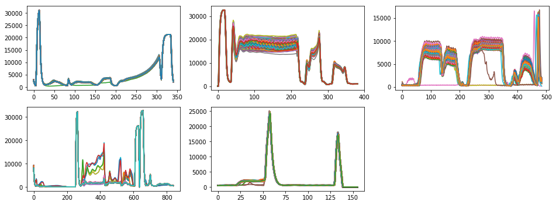

```python
plt.figure(figsize=(16,9))

plt.subplot(331)
for i in range(len(data_frame1)):
    plt.plot(data_frame1[i])

plt.subplot(332)
for i in range(len(data_frame2)):
    plt.plot(data_frame2[i])

plt.subplot(333)
for i in range(len(data_frame3)):
    plt.plot(data_frame3[i])

plt.subplot(334)
for i in range(len(data_frame4)):
    plt.plot(data_frame4[i])

plt.subplot(335)
for i in range(len(data_frame5)):
    plt.plot(data_frame5[i])
```

```
error index :  258
error index :  667
```

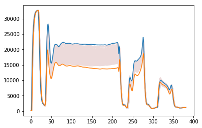

```python
data_frame = data_frame2
error_list = error_list2

plt.figure(figsize=(6,4))

err_dt = []
for i in range(len(data_frame)):
    if error_list[i] == 0:
        plt.plot(data_frame[i],"#ECDADA")
    else:
        err_dt.append(data_frame[i])
        print("error index : ", i)
for i in err_dt:
    plt.plot(i)
# plt.xlim([50,250]) # added
plt.show()
```

# Data가 처음 들어왔을 때 #n ~ 10까지?

- 비교대상 없이 그냥 누적 해서 `feature`들을 저장 해놓음.
- 측정 할 feature는 우선 `평균`, `variance`

## Warning 을 체크 하는 법?

- 체크를 하기 위해서는 여러가지 방법이 있겠다.
  1. var만큼 위아래 폭을 줘서 넘어가면 에러라고 본다? 이렇게 넘어간 time을 누적해서 체크 일정 비율을 넘어가면!?
  2. 꾸준하게 편차를 재서 이 편차의 합이 일정 비율을 넘어가면?
  3. *`data가 time corr.가 존재하는 것 같은데, 이런 경우 최근 dt개 데이터만 고려해야 할까?`*

```python
def func_chk(_data, _mean, _var, _Z_val):
    _cnt = 0;
    for _i in range(len(_data)):
        if _data[_i] > (_mean[_i] + _var[_i]*_Z_val) or _data[_i] < (_mean[_i] - _var[_i]*_Z_val):
            _cnt = _cnt + 1
    return _cnt/len(_data)

def model_01(data_frame, diff_ratio, Z_val, train_size):
    # initialize
    n = 1

    data_sum = data_frame[0]
    data_square_sum = data_frame[0]*data_frame[0]
    data_mean = data_sum/n
    data_var = data_square_sum/n - data_mean*data_mean
    data_sqrt = np.sqrt(data_var)

    over_cnt = [0]
    eval_anomaly = [0]


    for i in range(1,len(data_frame)):
        data, n = data_frame[i], i+1
        if i > train_size:
            over_cnt.append(func_chk(data,data_mean,data_sqrt,Z_val))
            if over_cnt[i] > diff_ratio :
                eval_anomaly.append(1)
                print("anomaly : ",i)
            else:
                eval_anomaly.append(0)
        else :
            over_cnt.append(0)
            eval_anomaly.append(0)

        data_sum = data_sum + data
        data_square_sum = data_square_sum + data*data
        data_mean = data_sum/n
        data_var = data_square_sum/n - data_mean*data_mean
        data_sqrt = np.sqrt(data_var)

    err_dt = []
    plt.figure(figsize=(8,6))
    plt.subplot(212)
    plt.title("Total Data")
    for i in range(len(data_frame)):
        if eval_anomaly[i] == 1: # anomaly!
#             print("anomaly : ",i)
            err_dt.append(data_frame[i])
        else:
            plt.plot(data_frame[i],"#ECDADA")
    for i in err_dt:
        plt.plot(i)

    plt.subplot(211)
    plt.title("Over count ratio")
    plt.plot(over_cnt)
    plt.plot([0,len(over_cnt)],[diff_ratio,diff_ratio],"r")


#     plt.subplot(222)
#     plt.title("Detect anomaly")
#     plt.plot(eval_anomaly)
    plt.tight_layout()
    plt.savefig("./Results/Fig_Z_val_"+str(Z_val)+"_diff_raio_"+str(diff_ratio)+".png", format='png', bbox_inches='tight')
    plt.show()
```

```
anomaly :  382
```

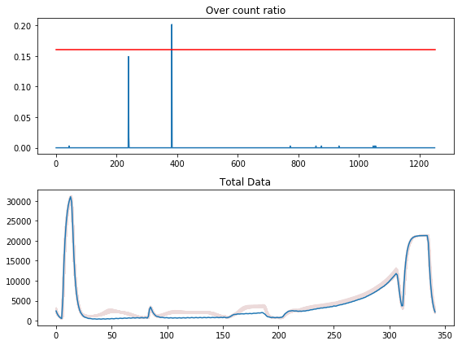

```
'\nanomaly : 382\n'
```

```python
# Global variance
Diff_ratio = 0.16
Z_Val = 11.
Train_size = 10

model_01(data_frame1, Diff_ratio, Z_Val, Train_size)
'''
anomaly : 382
'''
```

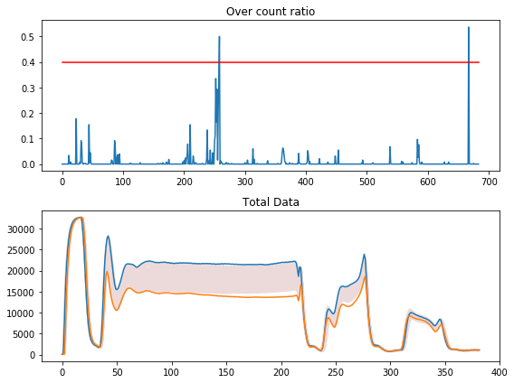

```python
# Global variance
Diff_ratio = 0.4
Z_Val = 3.
Train_size = 10

model_01(data_frame2, Diff_ratio, Z_Val, Train_size)
```

[output not shown]

```
anomaly :  66
anomaly :  706
anomaly :  1408
anomaly :  1425
```

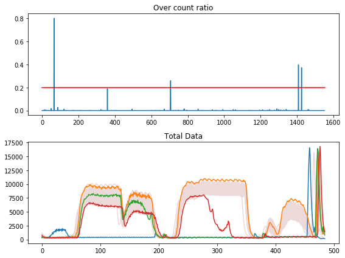

```python
# Global variance
Diff_ratio = 0.2
Z_Val = 3.9
Train_size = 10

model_01(data_frame3, Diff_ratio, Z_Val, Train_size)
```

```
anomaly :  757
anomaly :  758
anomaly :  778
anomaly :  779
anomaly :  780
anomaly :  892
anomaly :  893
```

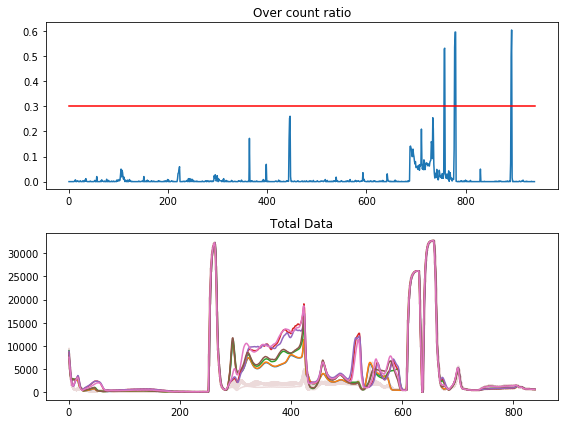

```python
# Global variance
Diff_ratio = 0.3
Z_Val = 3.
Train_size = 10

model_01(data_frame4, Diff_ratio, Z_Val, Train_size)
'''
anomaly : 690
anomaly : 693
anomaly : 694
anomaly : 757
anomaly : 758
anomaly : 778
anomaly : 779
anomaly : 780
anomaly : 892
anomaly : 893
'''
```

```
anomaly :  360
anomaly :  361
anomaly :  375
anomaly :  765
anomaly :  805
```

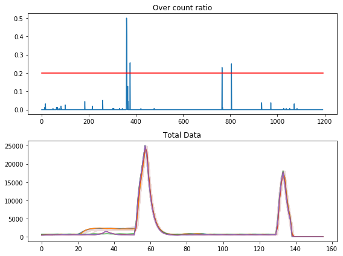

```
'\nanomaly : 375\nanomaly : 765\nanomaly : 805\n'
```

```python
# Global variance
Diff_ratio = 0.2
Z_Val = 4.
Train_size = 10

model_01(data_frame5, Diff_ratio, Z_Val, Train_size)
'''
anomaly : 375
anomaly : 765
anomaly : 805
'''
```

```python
def model_02(data_frame, diff_ratio, Z_val, train_size):
    # initialize
    n = 1

    data_sum = data_frame[0]
    data_square_sum = data_frame[0]*data_frame[0]
    data_mean = data_sum/n
    data_var = data_square_sum/n - data_mean*data_mean
    data_sqrt = np.sqrt(data_var)

    over_cnt = [0]
    eval_anomaly = [0]


    for i in range(1,len(data_frame)):
        data, n = data_frame[i], i+1
        if i > train_size:
            over_cnt.append(func_chk(data,data_mean,data_sqrt,Z_val))
            if over_cnt[i] > diff_ratio :
                eval_anomaly.append(1)
            else:
                eval_anomaly.append(0)
        else :
            over_cnt.append(0)
            eval_anomaly.append(0)

        data_sum = data_sum + data
        data_square_sum = data_square_sum + data*data
        data_mean = data_sum/n
        data_var = data_square_sum/n - data_mean*data_mean
        data_sqrt = np.sqrt(data_var)
    plt.scatter(np.arange(len(over_cnt)), over_cnt, label = str(Z_val))
```

```
anomaly : 382
```

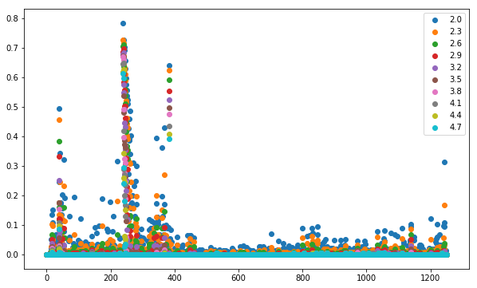

```python
# Global variance
Diff_ratio = 0.15
# Z_Val = 10.
Z_start = 2.
Z_end = 5.
Z_step = 0.3
Train_size = 10
dd = "1"

data = pd.read_csv('data_'+dd+'.csv', header=None, index_col=None)
data_frame = np.array(data[list(range(2,np.shape(data)[1]))])
error_list = list(data[0])
for i in range(len(error_list)):
    if  error_list[i] == 1:
        print("anomaly :",i)

plt.figure(figsize=(10,6))
for Z_Val in np.arange(Z_start,Z_end,Z_step):
    model_02(data_frame, Diff_ratio, Z_Val, Train_size)
plt.legend()
plt.show()
```

# To do

- Z-val을 뉴럴네트웍으로 학습하고싶다.
- cost func을 어떻게 정의하느냐가 관건